# Cannabis PGS in STAGE

Joëlle Pasman

November 19, 2025

# Prepare data

This code shows how polygenic risk scores were created to capture genetic risk for cannabis use to predict a set of outcomes in the STAGE dataset from the Swedish Twin Register. The genotype data are located at a different cluster space (Uppmax Bianca) than the phenotypic data and were linked by STR.

## Clean phenotype data

Documentation for these phenotypes can be requested from STR.

```r
library(tidyverse)
library(data.table)

raw <- fread("pheno_stage.csv")

# Cannabis

canpheno <- raw %>%
  mutate(can_maxfrq = ifelse(CANN_AMO == 1, CANNAMOV, NA)) %>%
  mutate(can_ever = ifelse(DRUGS_MARIJUAN == 1 | DRUGS_HASCH == 1, 1, NA)) %>%
  mutate(can_ever = ifelse(is.na(can_ever) & (DRUGS_MARIJUAN == 0 | DRUGS_HASCH == 0), 0, can_ever)) %>%
  mutate(can_agefirst = ifelse(AGE_CANN == 1, AGECV, NA)) %>%
  mutate(can_agefirst = ifelse(can_agefirst < 10, NA, can_agefirst)) %>%
  mutate(can_agemax = ifelse(AGECANMO == 1, AGECMV, NA)) %>%
  mutate(can_agemax = ifelse(can_agemax < 10, NA, can_agemax)) %>%
   mutate(across(c(can_maxfrq, can_agefirst, can_agemax), scale)) %>%
  select(idSTR, can_maxfrq, can_ever, can_agefirst, can_agemax)

fwrite(canpheno, "canpheno.tsv")


# Other substance us

drugspheno <- raw %>%
  mutate(opioids = pmax(DRUGS_OPIUM, DRUGS_MORPH, DRUGS_HEROIN, DRUGS_CODEIN, na.rm = T)) %>%
  mutate(stimulants = pmax(DRUGS_COCAINE, DRUGS_AMPHET, DRUGS_METHYLP, na.rm = T)) %>%
  mutate(ecstacy = DRUGS_ECSTACY) %>%
  mutate(halluci = pmax(DRUGS_LSD, DRUGS_MUSHROOM, na.rm = T)) %>%
  mutate(tranq = pmax(DRUGS_ROHYPNOL, DRUGS_SOPORIF, DRUGS_GHB, na.rm = T)) %>%
  mutate(steroids = pmax(DRUGS_GROWTHH, DRUGS_STEROIDS, na.rm = T)) %>%
   mutate(drugs_not_can = pmax(DRUGS_OPIUM, DRUGS_MORPH, DRUGS_HEROIN, DRUGS_CODEIN, DRUGS_COCAINE, DRUGS_AMPHET, DRUGS_METHYLP, DRUGS_ECSTACY, DRUGS_LSD, DRUGS_MUSHROOM, DRUGS_ROHYPNOL, DRUGS_SOPORIF, DRUGS_GHB, DRUGS_GROWTHH, DRUGS_STEROIDS, na.rm = T)) %>%
  mutate(alc_abuse = ifelse(X_ALC_ABUSE == 1, 1, NA)) %>%
  mutate(alc_abuse = ifelse(X_ALC_ABUSE == 0, 0, alc_abuse)) %>%
  mutate(smok_reg = ifelse(X_REGSM == 1, 1, 0)) %>%
  mutate(smok_reg = ifelse(is.na(smok_reg), 0, smok_reg)) %>%
   mutate(smok_ftnd = scale(X_FTNDSMOSCORE)) %>%
  select(idSTR, opioids, stimulants, ecstacy, halluci, tranq, steroids, drugs_not_can, alc_abuse, smok_reg, smok_ftnd)


fwrite(drugspheno, "drugspheno.tsv")


# Mental health

## Mental health dataset
## drop traits with <100 cases, except schizo

psychpheno <- raw %>%
  mutate(eatingdis = ifelse(EATDIS == 1, 1, NA)) %>%
  mutate(eatingdis = ifelse(EATDIS == 0, 0, eatingdis)) %>%
  mutate(mdd = ifelse(DEPRESS == 1 | X_DSM4DEP == 1, 1, NA)) %>%
  mutate(mdd = ifelse(is.na(mdd) & DEPRESS == 0, 0, mdd)) %>%
  mutate(mdd = ifelse(is.na(mdd) & X_DSM4DEP == 0, 0, mdd)) %>%
  mutate(phobia = ifelse(FOBIA == 1, 1, NA)) %>%
  mutate(phobia = ifelse(FOBIA == 0, 0, fobia)) %>%
  mutate(bip = ifelse(MANICDEP == 1, 1, NA)) %>%
  mutate(bip = ifelse(MANICDEP == 0, 0, bip)) %>%
  mutate(ocd = ifelse(OBSESS == 1, 1, NA)) %>%
  mutate(ocd = ifelse(OBSESS == 0, 0, ocd)) %>%
  mutate(panicdis = ifelse(PANIC == 1, 1, NA)) %>%
  mutate(panicdis = ifelse(PANIC == 0, 0, panicdis)) %>%
  mutate(substancedis = ifelse(DRUGSALC == 1, 1, NA)) %>%
  mutate(substancedis = ifelse(DRUGSALC == 0, 0, substancedis)) %>%
  mutate(schizo = ifelse(SCHIZO == 1, 1, NA)) %>%
  mutate(schizo = ifelse(SCHIZO == 0, 0, schizo)) %>%
  mutate(tourette = ifelse(TOURETTE == 1, 1, NA)) %>%
  mutate(tourette = ifelse(TOURETTE == 0, 0, tourette)) %>%
  mutate(impulsive = ifelse(IMPULSIV < 10, scale(IMPULSIV), NA)) %>%
  select(idSTR, eatingdis, mdd, fobia, bip, ocd, panicdis, substancedis, schizo, tourette, impulsive)

fwrite(psychpheno, "psychpheno.tsv")
```

## Clean sumstats

The summary statistics that will form the basis for the PGSs are prepared.

```r
# Ever use

CANNABIS_EVR <- fread("results/metal/MA_CANNABIS_EVR_250919.txt.gz")

CANNABIS_EVR <- CANNABIS_EVR %>%
  rename(beta = BETA) %>%
  mutate(CHR_BP = paste0(CHR, "_", BP)) %>%
  group_by(CHR_BP) %>%
  filter(n() == 1) %>%
  ungroup() %>%
  group_by(SNP) %>%
  arrange(desc(N)) %>%
  filter(n() == 1) %>%
  ungroup()

fwrite(CANNABIS_EVR, "results/metal/CANNABIS_EVR_formatted_forldpred.txt", sep = "\t")

# All-frequency

FREQ_MA <- fread("results/gsem/MA_FREQ_ALL_250919.txt.gz")

FREQ_MA <- FREQ_MA %>%
  rename(beta = BETA) %>%
  mutate(CHR_BP = paste0(CHR, "_", BP)) %>%
  group_by(CHR_BP) %>%
  filter(n() == 1) %>%
  ungroup() %>%
  group_by(SNP) %>%
  arrange(desc(N)) %>%
  filter(n() == 1) %>%
  ungroup()

fwrite(FREQ_MA, "results/gsem/FREQ_MA_formatted.txt", sep = "\t", quote = F, na = "NA")

# All-cannabis

FACTOR <- fread("results/gsem/MA_CANN_FACTOR_250919.txt.gz")

FACTOR <- FACTOR %>%
  rename(beta = BETA) %>%
  mutate(CHR_BP = paste0(CHR, "_", BP)) %>%
  group_by(CHR_BP) %>%
  filter(n() == 1) %>%
  ungroup() %>%
  group_by(SNP) %>%
  arrange(desc(N)) %>%
  filter(n() == 1) %>%
  ungroup()

fwrite(FACTOR, "results/gsem/CANNABIS_FACTOR_formatted.txt", sep = "\t", quote = F, na = "NA")
```

# Create PGS weighting scheme

Moving back to the server with the genetic data, relying on the CoMorMent containers (https://github.com/comorment/ldpred2_standalone) to run LDpred2 to create LD-score weighted polygenic risk scores.

```bash
# Ever use

echo -en '#!/bin/bash
#SBATCH --job-name=everpgs
#SBATCH -p node
#SBATCH -t 1:00:00
#SBATCH --array=1-22

export fileGenoRDS=stage_geno${SLURM_ARRAY_TASK_ID}.rds

export REFERENCE=$COMORMENT/containers/reference
export LDPRED2_REF=$COMORMENT/ldpred2_ref
export SINGULARITY_BIND=$REFERENCE:/REF,${LDPRED2_REF}:/ldpred2_ref
export RSCRIPT="singularity exec --home $PWD $SIF/r.sif Rscript"

# Generate PGS using LDPRED2-auto
$RSCRIPT $COMORMENT/containers/scripts/pgs/LDpred2/ldpred2.R --ldpred-mode auto \
 --merge-by-rsid \
 --effective-sample-size 560459 \
 --geno-file-rds $fileGenoRDS \
 --sumstats cannabis/CANNABIS_EVR_formatted_forldpred.txt \
 --out cannabis/CANNABIS_EVR${SLURM_ARRAY_TASK_ID}.auto

' > CANNABIS_EVR_ldpred2.sh

sbatch CANNABIS_EVR_ldpred2.sh


# All-frequency

echo -en '#!/bin/bash
#SBATCH --job-name=frq_ma_pgs
#SBATCH -p node
#SBATCH -t 1:00:00
#SBATCH --array=1-22

export fileGenoRDS=stage_geno${SLURM_ARRAY_TASK_ID}.rds

export REFERENCE=$COMORMENT/containers/reference
export LDPRED2_REF=$COMORMENT/ldpred2_ref
export SINGULARITY_BIND=$REFERENCE:/REF,${LDPRED2_REF}:/ldpred2_ref
export RSCRIPT="singularity exec --home $PWD $SIF/r.sif Rscript"

# Generate PGS using LDPRED2-auto
$RSCRIPT $COMORMENT/containers/scripts/pgs/LDpred2/ldpred2.R --ldpred-mode auto \
--merge-by-rsid \
 --col-n N \
 --geno-file-rds $fileGenoRDS \
 --sumstats cannabis/FREQ_MA_formatted.txt \
 --out cannabis/FREQ_MA${SLURM_ARRAY_TASK_ID}.auto

' > FREQ_MA_ldpred2.sh

sbatch FREQ_MA_ldpred2.sh


# All-cannabis

echo -en '#!/bin/bash
#SBATCH --job-name=factor_pgs
#SBATCH -p node
#SBATCH -t 1:00:00
#SBATCH --array=1-22

export fileGenoRDS=stage_geno${SLURM_ARRAY_TASK_ID}.rds

export REFERENCE=$COMORMENT/containers/reference
export LDPRED2_REF=$COMORMENT/ldpred2_ref
export SINGULARITY_BIND=$REFERENCE:/REF,${LDPRED2_REF}:/ldpred2_ref
export RSCRIPT="singularity exec --home $PWD $SIF/r.sif Rscript"

# Generate PGS using LDPRED2-auto
$RSCRIPT $COMORMENT/containers/scripts/pgs/LDpred2/ldpred2.R --ldpred-mode auto \
--merge-by-rsid \
 --col-n N \
 --geno-file-rds $fileGenoRDS \
 --sumstats cannabis/CANNABIS_FACTOR_formatted.txt \
 --out cannabis/CANNABIS_FACTOR${SLURM_ARRAY_TASK_ID}.auto

' > CANNABIS_FACTOR_ldpred2.sh

sbatch CANNABIS_FACTOR_ldpred2.sh
```

Concatenate the results (summing the per-chromosome scores).

```r
# Ever use

file_list <- list.files(pattern = "CANNABIS_EVR\\d+\\.auto")

data_list <- lapply(file_list, function(file) {
  df <- read.table(file, header = TRUE)
  file_num <- sub("\\.auto", "\\1", basename(file))
  df <- df %>%
    rename_with(~ paste0("pgs_", file_num), "score")
  return(df)
})

CANNABIS_EVR <- Reduce(function(x, y) merge(x, y, by = c("FID", "IID"), all = TRUE), data_list)

CANNABIS_EVR <- CANNABIS_EVR %>%
  mutate(CANNABIS_EVR_pgs = rowSums(select(., starts_with("pgs_CANNABIS_EVR")), na.rm = TRUE)) %>%
  select(FID, IID, CANNABIS_EVR_pgs)

fwrite(CANNABIS_EVR, "CANNABIS_EVR.auto")


# All-frequency

file_list <- list.files(pattern = "^FREQ_MA\\d+\\.auto$")

data_list <- lapply(file_list, function(file) {
  df <- read.table(file, header = TRUE)
  file_num <- sub("\\.auto", "\\1", basename(file))
  df <- df %>%
    rename_with(~ paste0("pgs_", file_num), "score")
  return(df)
})

FREQ_MA <- Reduce(function(x, y) merge(x, y, by = c("FID", "IID"), all = TRUE), data_list)

FREQ_MA <- FREQ_MA %>%
  mutate(FREQ_MA_pgs = rowSums(select(., starts_with("pgs_FREQ_MA")), na.rm = TRUE)) %>%
  select(FID, IID, FREQ_MA_pgs)

fwrite(FREQ_MA, "FREQ_MA.auto")


## All-cannabis

CANNABIS_FACTOR <- Reduce(function(x, y) merge(x, y, by = c("FID", "IID"), all = TRUE), data_list)

CANNABIS_FACTOR <- CANNABIS_FACTOR %>%
  mutate(CANNABIS_FACTOR_pgs = rowSums(select(., starts_with("pgs_CANNABIS_FACTOR")), na.rm = TRUE)) %>%
  select(FID, IID, CANNABIS_FACTOR_pgs)

fwrite(CANNABIS_FACTOR, "CANNABIS_FACTOR.auto")
```

# Evaluate PGS effects

Linking of PGS and phenotype files was performed by STR and analyses were done on the Uppmax HPC. We approached (Nagelkerke’s) R2 difference between models with an without the PGSs using bootstrapping, using bca where possible. All continuous predictors and outcomes were standardised. For binary outcomes, logistic regression was used.

```r
library(tidyverse)
library(data.table)
library(glue)
library(fmsb)
library(boot)

pgs1 <- fread("freq_ma_stage_linked.txt")
pgs2 <- fread("cannabis_evr_stage_linked.txt")
pgs3 <- fread("cannabis_factor_stage_linked.txt")
canpheno <- fread("canpheno.tsv")
drugspheno <- fread("drugspheno.tsv")
psychpheno <- fread("psychpheno.tsv")
covar <- fread("sex_birthyear_pcs.csv")

pheno <- canpheno %>%
  inner_join(covar, by=c("idSTR"="stage_id")) %>%
  inner_join(pgs1, by=c("idSTR"="stage_id")) %>%
  inner_join(pgs2, by=c("idSTR"="stage_id")) %>%
  inner_join(pgs3, by=c("idSTR"="stage_id")) %>%
  left_join(drugspheno) %>%
  left_join(psychpheno)

# Check sex and age distribution

pheno %>%
  filter(!is.na(FREQ_MA_pgs)) %>%
  group_by(sex) %>%
  summarise(n())

pheno %>%
  filter(!is.na(FREQ_MA_pgs)) %>%
  summarise(range(birth_y, na.rm = T))

pheno %>%
  filter(!is.na(FREQ_MA_pgs)) %>%
  summarise(mean(birth_y, na.rm = T), sd(birth_y, na.rm = T))

# Find continuous variables to standardise
is_bin <- map_lgl(pheno, ~ length(unique(.)) <= 3)
traits_bin <- colnames(pheno)[is_bin]
traits_con <- colnames(pheno)[!is_bin]
traits_con <- traits_con[-1]
traits_bin <- traits_bin[-2]

pheno <- pheno %>%
  mutate(across(all_of(traits_con), ~ scale(.)))

# Regression functions

evalpgs <- function(trait, pgs) {
  f1 <- as.formula(glue("{trait} ~ {pgs} + sex + birth_y + PC1_EU + PC2_EU + PC3_EU + PC4_EU + PC5_EU + PC6_EU + PC7_EU + PC8_EU + PC9_EU + PC10_EU"))
  res <- summary(x <- glm(data = pheno, f1, family = "binomial"))$coefficients
  data.frame(res, parameter = row.names(res))
}

evalpgs_con <- function(trait, pgs) {
  f1 <- as.formula(glue("{trait} ~ {pgs} + sex + birth_y + PC1_EU + PC2_EU + PC3_EU + PC4_EU + PC5_EU + PC6_EU + PC7_EU + PC8_EU + PC9_EU + PC10_EU"))
  res <- summary(x <- lm(data = pheno, f1))$coefficients
  data.frame(res, parameter = row.names(res))
}

# R2 functions

#### R2 with bootstrapping to get SE
##### Binary

evalpgsR2_bin_boot <- function(trait, pgs, data = pheno,
                               n_boot = 1000, seed = NULL,
                               parallel = FALSE, n_cores = max(1, parallel::detectCores() - 1)) {
  if (!is.null(seed)) set.seed(seed)

  f1 <- as.formula(glue("{trait} ~ {pgs} + sex + birth_y + PC1_EU + PC2_EU + PC3_EU + PC4_EU + PC5_EU + PC6_EU + PC7_EU + PC8_EU + PC9_EU + PC10_EU"))
  f2 <- as.formula(glue("{trait} ~          sex + birth_y + PC1_EU + PC2_EU + PC3_EU + PC4_EU + PC5_EU + PC6_EU + PC7_EU + PC8_EU + PC9_EU + PC10_EU"))

  # point estimate
  fit1 <- glm(f1, data = data, family = binomial())
  fit2 <- glm(f2, data = data, family = binomial())
  delta_r2_hat <- as.numeric(fmsb::NagelkerkeR2(fit1)$R2 - fmsb::NagelkerkeR2(fit2)$R2)

  # bootstrap statistic
  stat_fn <- function(d, idx) {
    d <- d[idx, , drop = FALSE]
    f1b <- glm(f1, data = d, family = binomial())
    f2b <- glm(f2, data = d, family = binomial())
    as.numeric(fmsb::NagelkerkeR2(f1b)$R2 - fmsb::NagelkerkeR2(f2b)$R2)
  }

  b <- boot::boot(
    data = data,
    statistic = stat_fn,
    R = n_boot,
    parallel = if (parallel) "multicore" else "no",
    ncpus = if (parallel) n_cores else 1
  )

  boots <- b$t[, 1]
  boots <- boots[is.finite(boots)]
  se <- stats::sd(boots)

  # BCa CI
  bca_obj <- try(boot::boot.ci(b, type = "bca"), silent = TRUE)
  if (inherits(b, "try-error") || is.null(bca_obj$bca)) { # can happen in the leave-one-out jackknife step (boot.ci)
    ci <- stats::quantile(boots, probs = c(0.025, 0.975), na.rm = TRUE) # not bias-adjusted as bca, but still asymmetrical CI
    ci_low  <- unname(ci[1]); ci_high <- unname(ci[2])
  } else {
    ci_low  <- bca_obj$bca[4] # this is bias-adjusted
    ci_high <- bca_obj$bca[5]
  }

  # bootstrap p-value for H0: ΔR² = 0, one-sided (ΔR² > 0)
  B <- length(boots)
  p_boot <- (sum(boots <= 0, na.rm = TRUE) + 1) / (B + 1)

  tibble(
    pgs       = pgs,
    R2        = delta_r2_hat,
    se        = se,
    ci95_low  = ci_low,
    ci95_high = ci_high,
    P_R2      = p_boot      # from same bootstrap as CI
  )
}

##### Continuous

evalpgsR2_con_boot <- function(trait, pgs, data = pheno,
                               n_boot = 1000, seed = NULL,
                               parallel = FALSE, n_cores = max(1, parallel::detectCores() - 1)) {
  if (!is.null(seed)) set.seed(seed)

  f1 <- as.formula(glue("{trait} ~ {pgs} + sex + birth_y + PC1_EU + PC2_EU + PC3_EU + PC4_EU + PC5_EU + PC6_EU + PC7_EU + PC8_EU + PC9_EU + PC10_EU"))
  f2 <- as.formula(glue("{trait} ~ sex + birth_y + PC1_EU + PC2_EU + PC3_EU + PC4_EU + PC5_EU + PC6_EU + PC7_EU + PC8_EU + PC9_EU + PC10_EU"))

  # point estimate
  fit1 <- lm(f1, data = data)
  fit2 <- lm(f2, data = data)
  delta_r2_hat <- summary(fit1)$r.squared - summary(fit2)$r.squared

  # bootstrap statistic
  stat_fn <- function(d, idx) {
    d <- d[idx, , drop = FALSE]
    f1b <- lm(f1, data = d)
    f2b <- lm(f2, data = d)
    summary(f1b)$r.squared - summary(f2b)$r.squared
  }

  b <- boot::boot(
    data = data,
    statistic = stat_fn,
    R = n_boot,
    parallel = if (parallel) "multicore" else "no",
    ncpus = if (parallel) n_cores else 1
  )

  boots <- b$t[, 1]
  boots <- boots[is.finite(boots)]
  se <- stats::sd(boots)

  # BCa CI
  bca_obj <- try(boot::boot.ci(b, type = "bca"), silent = TRUE)
  if (inherits(bca_obj, "try-error") || is.null(bca_obj$bca)) {
    ci <- stats::quantile(boots, probs = c(0.025, 0.975), na.rm = TRUE)
    ci_low  <- unname(ci[1]); ci_high <- unname(ci[2])
  } else {
    ci_low  <- bca_obj$bca[4]
    ci_high <- bca_obj$bca[5]
  }

  # bootstrap p-value for H0: ΔR² = 0, one-sided (ΔR² > 0)
  B <- length(boots)
  p_boot <- (sum(boots <= 0, na.rm = TRUE) + 1) / (B + 1)

  tibble(
    pgs       = pgs,
    R2        = delta_r2_hat,
    se        = se,
    ci95_low  = ci_low,
    ci95_high = ci_high,
    P_R2      = p_boot
  )
}



# Trait combinations

traits_con <- traits_con[c(1:3, 28,29)]
pgs <- colnames(pheno)[c(28:30)]
combos_bin <- crossing(pgs, traits_bin)
combos_con <- crossing(pgs, traits_con)

# Running the analyses

results_bin <- map2(combos_bin$traits_bin, combos_bin$pgs, evalpgs)
results_r2_bin <- map2(combos_bin$traits_bin, combos_bin$pgs, evalpgsR2_bin)
results_r2_bin <- map2(combos_bin$traits_bin, combos_bin$pgs, evalpgsR2_bin_boot, n_boot = 2000, seed = 42)
saveRDS(results_r2_bin, "results_r2_bin.RDS")

results_con <- map2(combos_con$traits_con, combos_con$pgs, evalpgs_con)
results_r2_con <- map2(combos_con$traits_con, combos_con$pgs, evalpgsR2_con)
results_r2_con <- map2(combos_con$traits_con, combos_con$pgs, evalpgsR2_con_boot, n_boot = 2000, seed = 42)
saveRDS(results_r2_con, "results_r2_con.RDS")

# Munging results

names(results_bin) <- combos_bin$traits_bin
names(results_con) <- combos_con$traits_con
names(results_r2_bin) <- combos_bin$traits_bin
names(results_r2_con) <- combos_con$traits_con

results_bin_df <- rbindlist(results_bin, idcol = T)
results_con_df <- rbindlist(results_con, idcol = T)
results_r2_bin_df <- rbindlist(results_r2_bin, idcol = T)
results_r2_con_df <- rbindlist(results_r2_con, idcol = T)

colnames(results_bin_df) <- c("outcome", "b", "SE", "teststatistic", "p", "predictor")
colnames(results_con_df) <- c("outcome", "b", "SE", "teststatistic", "p", "predictor")

colnames(results_r2_bin_df) <- c("outcome", "predictor", "R2", "R2_se", "R2_ci95_low", "R2_ci95_high","R2_p")
colnames(results_r2_con_df) <- c("outcome", "predictor", "R2", "R2_se", "R2_ci95_low", "R2_ci95_high","R2_p")


results_bin_df <- results_bin_df %>% inner_join(results_r2_bin_df)
results_con_df <- results_con_df %>% inner_join(results_r2_con_df)

fwrite(rbind(results_bin_df, results_con_df, fill = T), "prs_results.tsv")
```

Below is a small check to see how often BCa is used and how often just percentiles for the derivation of the CI of the R2.

```r
# Binary

diag_jackknife_bin <- function(trait, pgs, data = pheno) {
  f1 <- as.formula(paste(
    trait, "~", pgs,
    "+ sex + birth_y",
    "+ PC1_EU + PC2_EU + PC3_EU + PC4_EU + PC5_EU",
    "+ PC6_EU + PC7_EU + PC8_EU + PC9_EU + PC10_EU"
  ))
  f2 <- as.formula(paste(
    trait, "~",
    "sex + birth_y",
    "+ PC1_EU + PC2_EU + PC3_EU + PC4_EU + PC5_EU",
    "+ PC6_EU + PC7_EU + PC8_EU + PC9_EU + PC10_EU"
  ))

  n  <- nrow(data)
  ok <- logical(n)

  for (i in seq_len(n)) {
    d <- data[-i, , drop = FALSE]
    out <- try({
      m1 <- glm(f1, data = d, family = binomial())
      m0 <- glm(f2, data = d, family = binomial())
      fmsb::NagelkerkeR2(m1)$R2 - fmsb::NagelkerkeR2(m0)$R2
    }, silent = TRUE)
    ok[i] <- !(inherits(out, "try-error") || !is.finite(out))
  }

  data.frame(
    trait = trait,
    pgs   = pgs,
    jackknife_ok     = all(ok),
    jackknife_n_fail = sum(!ok)
  )
}

# Continuous

diag_jackknife_con <- function(trait, pgs, data = pheno) {
  f1 <- as.formula(glue("{trait} ~ {pgs} + sex + birth_y + PC1_EU + PC2_EU + PC3_EU + PC4_EU + PC5_EU + PC6_EU + PC7_EU + PC8_EU + PC9_EU + PC10_EU"))
  f2 <- as.formula(glue("{trait} ~          sex + birth_y + PC1_EU + PC2_EU + PC3_EU + PC4_EU + PC5_EU + PC6_EU + PC7_EU + PC8_EU + PC9_EU + PC10_EU"))

  n  <- nrow(data)
  ok <- logical(n)

  for (i in seq_len(n)) {
    d <- data[-i, , drop = FALSE]
    out <- try({
      m1 <- lm(f1, data = d)
      m0 <- lm(f2, data = d)
      summary(m1)$r.squared - summary(m0)$r.squared
    }, silent = TRUE)
    ok[i] <- !(inherits(out, "try-error") || !is.finite(out))
  }

  tibble::tibble(
    trait            = trait,
    pgs              = pgs,
    jackknife_ok     = all(ok),
    jackknife_n_fail = sum(!ok)
  )
}

jackknife_bin <- map2(combos_bin$traits_bin, combos_bin$pgs, diag_jackknife_bin)
jackknife_con <- map2(combos_con$traits_con, combos_con$pgs, diag_jackknife_con)

fwrite(rbindlist(jackknife_bin), "jackknife_diag_bin.tsv")
fwrite(rbindlist(jackknife_con), "jackknife_diag_con.tsv")
```

# Figure 4: pgs results

Next, we plot results, first inspecting the regression weights:

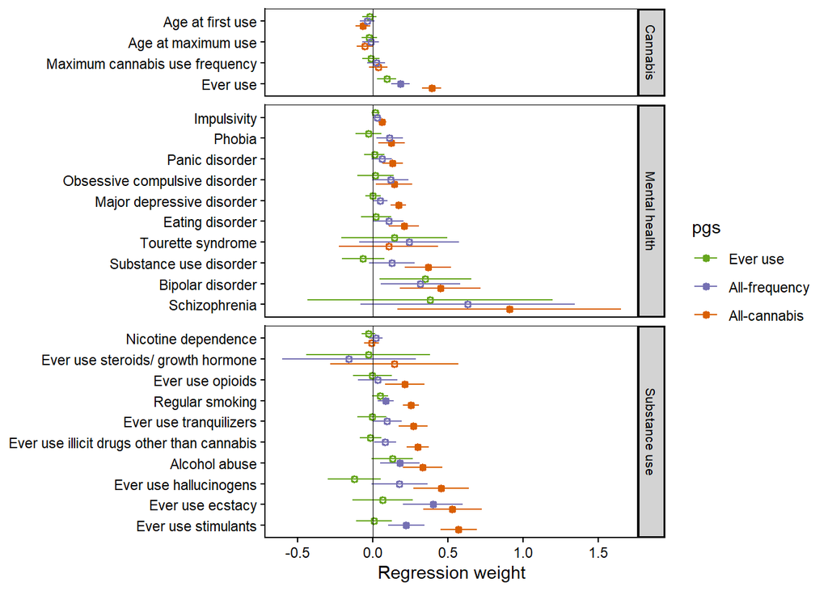

```r
library(readxl)
library(tidyverse)
library(data.table)
library(scales)
library(patchwork)

res <- fread("results/prs/prs_results.tsv")
labels <- read_excel("scripts/prs/outcome_labels.xlsx")

res <- res %>%
  left_join(labels, by=c("outcome"="name")) %>%
  select(!(item)) %>%
  filter(predictor != "(Intercept)") %>%
  mutate(predictor = dplyr::recode(predictor, "CANNABIS_EVR_prs" = "Ever use",
                            "CANNABIS_FACTOR_prs" = "All-cannabis",
                            "FREQ_MA_prs" = "All-frequency")) %>%
  rename(pgs = predictor) %>%
  group_by(pgs) %>%
  mutate(p_fdr = p.adjust(p, method = "BH"),
         p_fdr_bin = ifelse(p_fdr < .05, "*", "")) %>%
  ungroup() %>%
  mutate(pgs = factor(pgs, levels = c("Ever use", "All-frequency", "All-cannabis"))) %>%
  group_by(outcome) %>%
  mutate(maxval = max(b)) %>%
  ungroup() %>%
  arrange(maxval)

res <- res %>%
  mutate(label = factor(.$label, levels = unique(res$label)))


plt_com <- ggplot(subset(res, pgs == "Ever use" | pgs == "All-frequency" | pgs == "All-cannabis"),
                  aes(x = b, y = fct_rev(label), color = pgs, shape = p_fdr_bin, fill = p_fdr_bin)) +
  geom_pointrange(aes(xmin = b - 1.96 * as.numeric(SE), xmax = b + 1.96 * as.numeric(SE)),
                  position = position_dodge(width = -0.65),
                  size = 0.3) +
  geom_vline(xintercept = 0, size = 0.15) +
  facet_grid(Category ~ ., scales = "free", space = "free_y") +
  theme(axis.title.y = element_blank()) +
  theme_classic() +
  theme(axis.title.y = element_blank(),
        strip.text = element_text(colour = 'black', size = 8),
        strip.background = element_rect(fill = "lightgrey", color = "black"),
        panel.border = element_rect(color = "black", fill = NA),
        plot.title = element_text(size = 10, face = "bold", hjust = 0.5)
  ) +
  scale_colour_manual(values = c("#66a61e", "#7570b3", "#d95f02")) +
  xlab("Regression weight") +
  scale_shape_manual(values = c(1, 19)) +
  scale_fill_manual(values = c("white", NA)) +
  guides(shape = "none", fill = "none")

plt_com
```

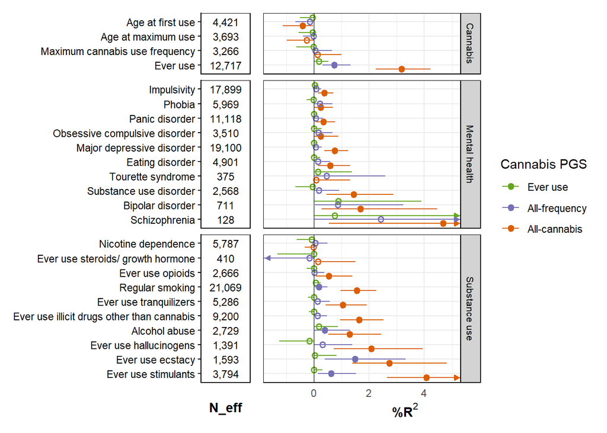

```r
res2 <- res %>%
  mutate(
      s = ifelse(b < 0, -1, 1),
      R2 = s * R2,
      lo = s * R2_ci95_high,
      hi = s * R2_ci95_low,
      R2_ci95_low  = pmin(lo, hi),
      R2_ci95_high = pmax(lo, hi)
    ) %>%
  select(-s, -lo, -hi) %>%
  mutate(R2 = R2*100, R2_se = R2_se *100,
         R2_ci95_low = R2_ci95_low * 100,
         R2_ci95_high = R2_ci95_high *100) %>%
  group_by(Category) %>%
  mutate(
    ypos = dense_rank(desc(label)),   # ranks within each Category, reversed
    ypos = case_when(
      pgs == "Ever use"     ~ ypos + 0.27,
      pgs == "All-cannabis" ~ ypos - 0.27,
      TRUE                  ~ ypos
    )) %>%
  mutate(
    N_cases = as.numeric(N_cases),
    N_controls = as.numeric(N_controls),
    N = as.numeric(N),
    N_eff = ifelse(!is.na(N_cases),
                   4 * N_cases * N_controls / (N_cases + N_controls),
                   N)
  ) %>%
  group_by(pgs) %>%
  mutate(R2_p_fdr = p.adjust(R2_p, method = "BH"),
         R2_p_fdr_bin = ifelse(p_fdr < .05, "*", "")) %>%
  mutate(direction = ifelse(b<0, "-", " "))

plt_com <- ggplot(subset(res2, pgs == "Ever use" | pgs == "All-frequency" | pgs == "All-cannabis"),
                  aes(x = R2, xmin = R2_ci95_low, xmax = R2_ci95_high,
              y = fct_rev(label), color = fct_rev(pgs),  shape = R2_p_fdr_bin, fill = R2_p_fdr_bin)) +
  geom_pointrange(position = position_dodge(width = 0.8), size = 0.4, fatten = 4) +
  geom_vline(xintercept = 0, size = 0.15) +
  facet_grid(Category ~ ., scales = "free", space = "free_y") +
  coord_cartesian(xlim = c(-1.5, 5)) +
  geom_segment(
    data = subset(res2, R2_ci95_high > 5),
    aes(x = 4, xend = 5.25, y =  ypos,
        color = fct_rev(pgs)),
    # pos = position_dodge2(width = 1, reverse = FALSE),
    arrow = arrow(length = unit(1.5, "mm"), type = "closed"),
    show.legend = FALSE
  ) +
    geom_segment(
    data = subset(res2, R2_ci95_low < - 1.5),
    aes(x = -1, xend = -1.75, y = ypos,
        color = pgs),
    arrow = arrow(length = unit(1.5, "mm"), type = "closed"),
    show.legend = FALSE
  ) +
  theme(axis.title.y = element_blank()) +
  theme_minimal() +
  theme(axis.title.y = element_blank(),
        axis.text.y = element_blank(),
        axis.title.x = element_text(hjust = 0.75),
        strip.text = element_text(colour = 'black', size = 8),
        strip.background = element_rect(fill = "lightgrey", color = "black"),
        panel.border = element_rect(color = "black", fill = NA),
        plot.title = element_text(size = 10, face = "bold", hjust = 0.5)
  ) +
  scale_colour_manual(
        name = "Cannabis PGS",
        values = c("Ever use" = "#66a61e", "All-frequency" = "#7570b3", "All-cannabis" = "#d95f02"),
        breaks = c("Ever use", "All-frequency", "All-cannabis")
      ) +
  xlab(expression(bold("%R"^2))) +
  scale_shape_manual(values = c(1, 19)) +
  scale_fill_manual(values = c("white", NA)) +
  guides(shape = "none", fill = "none")


plt_com_N <- ggplot(subset(res2, pgs == "Ever use"),
              aes(x = 5, y = fct_rev(label))) +
  facet_grid(Category ~ ., scales = "free", space = "free_y") +
  geom_text(aes(label = comma(N_eff)), size = 3) +
    theme(axis.title.y = element_blank()) +
  theme_classic() +
  theme(axis.title.y = element_blank(),
        axis.text.x = element_blank(),
        axis.ticks.x = element_blank(),
        strip.text = element_blank(),
        strip.background = element_blank(),
        panel.border = element_rect(color = "black", fill = NA)) +
  xlab(expression(bold("N_eff")))


plt_combi <- plt_com_N + plt_com + plot_layout(widths = c(0.2, 0.8))
plt_combi
```

```r
ggsave("results/prs/pgs_res_com_R2.svg", plt_combi, width = 7.5, height = 7.5)
ggsave("results/prs/pgs_res_com_R2.png", plt_combi, width = 7.5, height = 7.5)
```

# Supplementary Table Sx: full pgs results

For the supplement, we create a table with the full results. Here the first 20 rows are shown.

```r
restable <- res2 %>%
  select(Category, pgs, label, b, SE, p, p_fdr, R2, R2_ci95_low, R2_ci95_high, R2_p, R2_p_fdr, N_cases, N_controls, N, N_eff)

fwrite(restable, "results/prs/pgs_results_table.csv")

kable(head(restable, n=20))
```

| Category | pgs | label | b | SE | p | p_fdr | R2 | R2_ci95_low | R2_ci95_high | R2_p | R2_p_fdr | N_cases | N_controls | N | N_eff |
| --- | --- | --- | --- | --- | --- | --- | --- | --- | --- | --- | --- | --- | --- | --- | --- |
| Cannabis | Ever use | Age at first use | -0.0221628 | 0.0244606 | 0.3650497 | 0.8562959 | -0.0506937 | -0.5089147 | -0.0002572 | 0.0004998 | 0.0005000 | NA | NA | 4421 | 4421.000 |
| Cannabis | All-cannabis | Age at first use | -0.0657957 | 0.0255592 | 0.0101409 | 0.0143165 | -0.4076304 | -1.1217975 | -0.0349591 | 0.0004998 | 0.0005000 | NA | NA | 4421 | 4421.000 |
| Cannabis | All-frequency | Age at first use | -0.0386356 | 0.0251843 | 0.1252128 | 0.1669505 | -0.1451816 | -0.6744737 | -0.0010196 | 0.0004998 | 0.0005215 | NA | NA | 4421 | 4421.000 |
| Cannabis | Ever use | Age at maximum use | -0.0227880 | 0.0266386 | 0.3924690 | 0.8562959 | -0.0552500 | -0.5481004 | -0.0002207 | 0.0004998 | 0.0005000 | NA | NA | 3693 | 3693.000 |
| Cannabis | All-cannabis | Age at maximum use | -0.0518487 | 0.0281219 | 0.0654649 | 0.0785579 | -0.2560900 | -0.9797610 | -0.0027599 | 0.0004998 | 0.0005000 | NA | NA | 3693 | 3693.000 |
| Cannabis | All-frequency | Age at maximum use | -0.0132612 | 0.0280748 | 0.6367590 | 0.6367590 | -0.0168521 | -0.3988024 | -0.0000643 | 0.0004998 | 0.0005215 | NA | NA | 3693 | 3693.000 |
| Substance use | Ever use | Nicotine dependence | -0.0289839 | 0.0238210 | 0.2238788 | 0.7675844 | -0.0882498 | -0.6134150 | -0.0001702 | 0.0004998 | 0.0005000 | NA | NA | 5787 | 5787.000 |
| Substance use | All-cannabis | Nicotine dependence | -0.0099442 | 0.0250829 | 0.6918224 | 0.6918224 | -0.0093768 | -0.3330857 | -0.0000947 | 0.0004998 | 0.0005000 | NA | NA | 5787 | 5787.000 |
| Substance use | All-frequency | Nicotine dependence | 0.0205215 | 0.0239302 | 0.3912626 | 0.4695152 | 0.0438573 | 0.0000743 | 0.4853716 | 0.0004998 | 0.0005215 | NA | NA | 5787 | 5787.000 |
| Cannabis | Ever use | Maximum cannabis use frequency | -0.0121015 | 0.0294160 | 0.6808697 | 0.9633376 | -0.0155996 | -0.6351041 | -0.0001719 | 0.0004998 | 0.0005000 | NA | NA | 3266 | 3266.000 |
| Cannabis | All-cannabis | Maximum cannabis use frequency | 0.0365642 | 0.0314627 | 0.2454381 | 0.2805006 | 0.1243491 | 0.0004620 | 1.0043507 | 0.0004998 | 0.0005000 | NA | NA | 3266 | 3266.000 |
| Cannabis | All-frequency | Maximum cannabis use frequency | 0.0227688 | 0.0307721 | 0.4595143 | 0.5251591 | 0.0504448 | 0.0002040 | 0.6590620 | 0.0004998 | 0.0005215 | NA | NA | 3266 | 3266.000 |
| Mental health | Ever use | Impulsivity | 0.0166202 | 0.0119540 | 0.1644705 | 0.6687453 | 0.0274699 | 0.0000659 | 0.1489999 | 0.0004998 | 0.0005000 | NA | NA | 17899 | 17899.000 |
| Mental health | All-cannabis | Impulsivity | 0.0628764 | 0.0120855 | 0.0000002 | 0.0000006 | 0.3832680 | 0.1440412 | 0.7111494 | 0.0004998 | 0.0005000 | NA | NA | 17899 | 17899.000 |
| Mental health | All-frequency | Impulsivity | 0.0288487 | 0.0119215 | 0.0155506 | 0.0533165 | 0.0831694 | 0.0037891 | 0.2619695 | 0.0004998 | 0.0005215 | NA | NA | 17899 | 17899.000 |
| Mental health | Ever use | Phobia | -0.0292271 | 0.0437943 | 0.5045344 | 0.9023559 | -0.0147636 | -0.2579015 | -0.0000656 | 0.0004998 | 0.0005000 | 1651 | 15527 | 17178 | 5969.281 |
| Mental health | All-cannabis | Phobia | 0.1235021 | 0.0449402 | 0.0059934 | 0.0089902 | 0.2522266 | 0.0236575 | 0.6915469 | 0.0004998 | 0.0005000 | 1651 | 15527 | 17178 | 5969.281 |
| Mental health | All-frequency | Phobia | 0.1119916 | 0.0450131 | 0.0128473 | 0.0513890 | 0.2070009 | 0.0113229 | 0.6775645 | 0.0004998 | 0.0005215 | 1651 | 15527 | 17178 | 5969.281 |
| Mental health | Ever use | Panic disorder | 0.0103668 | 0.0342635 | 0.7622252 | 0.9633376 | 0.0021541 | 0.0000375 | 0.1364221 | 0.0004998 | 0.0005000 | 3208 | 20807 | 24015 | 11117.861 |
| Mental health | All-cannabis | Panic disorder | 0.1331053 | 0.0348609 | 0.0001344 | 0.0002482 | 0.3423093 | 0.0827709 | 0.7667445 | 0.0004998 | 0.0005000 | 3208 | 20807 | 24015 | 11117.861 |